# Iris Dataset Analysis

## About the Data

The dataset contains information about three species of iris flowers: **Iris setosa**, **Iris versicolor**, and **Iris virginica**.

The data includes measurements of four features: **sepal length**, **sepal width**, **petal length**, and **petal width**.

Each row in the dataset represents a single flower, and the measurement values are provided in centimeters.

The dataset consists of 150 samples, with 50 for each species. It is widely used as a fundamental dataset for testing classification algorithms, as well as in data science and machine learning studies.

**Columns:**

- **sepal length (cm)** - Length of the sepal in centimeters
- **sepal width (cm)** - Width of the sepal in centimeters
- **petal length (cm)** - Length of the petal in centimeters
- **petal width (cm)** - Width of the petal in centimeters
- **species** - Species of the iris (setosa, versicolor, virginica)

|  | długość kielicha (sepal length) | szerokość kielicha (sepal width) | długość płatka (petal length) | szerokość płatka (petal width) | klasa (class) |
| --- | --- | --- | --- | --- | --- |
| 0 | 5.1 | 3.5 | 1.4 | 0.2 | Iris-setosa |
| 1 | 4.9 | 3.0 | 1.4 | 0.2 | Iris-setosa |
| 2 | 4.7 | 3.2 | 1.3 | 0.2 | Iris-setosa |
| 3 | 4.6 | 3.1 | 1.5 | 0.2 | Iris-setosa |
| 4 | 5.0 | 3.6 | 1.4 | 0.2 | Iris-setosa |
| ... | ... | ... | ... | ... | ... |
| 145 | 6.7 | 3.0 | 5.2 | 2.3 | Iris-virginica |
| 146 | 6.3 | 2.5 | 5.0 | 1.9 | Iris-virginica |
| 147 | 6.5 | 3.0 | 5.2 | 2.0 | Iris-virginica |
| 148 | 6.2 | 3.4 | 5.4 | 2.3 | Iris-virginica |
| 149 | 5.9 | 3.0 | 5.1 | 1.8 | Iris-virginica |

150 rows × 5 columns

## General Data Overview

The dataset consists of 5 columns. The first 4 columns contain floating-point numbers, and the last column contains categorical data. The dataset does not have any missing values. There are 3 duplicated rows, but we will not address them as it's entirely possible to obtain the same measurements from two different samples (flowers).

Simply put, the data is clean and does not require preprocessing—a good start.

```
<class 'pandas.core.frame.DataFrame'>
RangeIndex: 150 entries, 0 to 149
Data columns (total 5 columns):
 #   Column                            Non-Null Count  Dtype
---  ------                            --------------  -----
 0   długość kielicha (sepal length)   150 non-null    float64
 1   szerokość kielicha (sepal width)  150 non-null    float64
 2   długość płatka (petal length)     150 non-null    float64
 3   szerokość płatka (petal width)    150 non-null    float64
 4   klasa (class)                     150 non-null    object
dtypes: float64(4), object(1)
memory usage: 6.0+ KB
```

```
długość kielicha (sepal length)     0
szerokość kielicha (sepal width)    0
długość płatka (petal length)       0
szerokość płatka (petal width)      0
klasa (class)                       0
dtype: int64
```

```
3
```

|  | długość kielicha (sepal length) | szerokość kielicha (sepal width) | długość płatka (petal length) | szerokość płatka (petal width) | klasa (class) |
| --- | --- | --- | --- | --- | --- |
| 34 | 4.9 | 3.1 | 1.5 | 0.1 | Iris-setosa |
| 37 | 4.9 | 3.1 | 1.5 | 0.1 | Iris-setosa |
| 142 | 5.8 | 2.7 | 5.1 | 1.9 | Iris-virginica |

## Brief Overview of Individual Variables

After preparing the data and analyzing the basic mean values for each class, we clearly see that the different iris species vary in their dimensions. The differences are most evident when comparing the length and width of the petals. Below are the corresponding charts.

In the next stage of our analysis, we will examine whether these differences are consistent throughout the entire sample.

|  | sepal_length | sepal_width | petal_length | petal_width | species |
| --- | --- | --- | --- | --- | --- |
| 0 | 5.1 | 3.5 | 1.4 | 0.2 | Iris-setosa |

|  | species | sepal_length | sepal_width | petal_length | petal_width |
| --- | --- | --- | --- | --- | --- |
| 0 | Iris-setosa | 5.006 | 3.418 | 1.464 | 0.244 |
| 1 | Iris-versicolor | 5.936 | 2.770 | 4.260 | 1.326 |
| 2 | Iris-virginica | 6.588 | 2.974 | 5.552 | 2.026 |

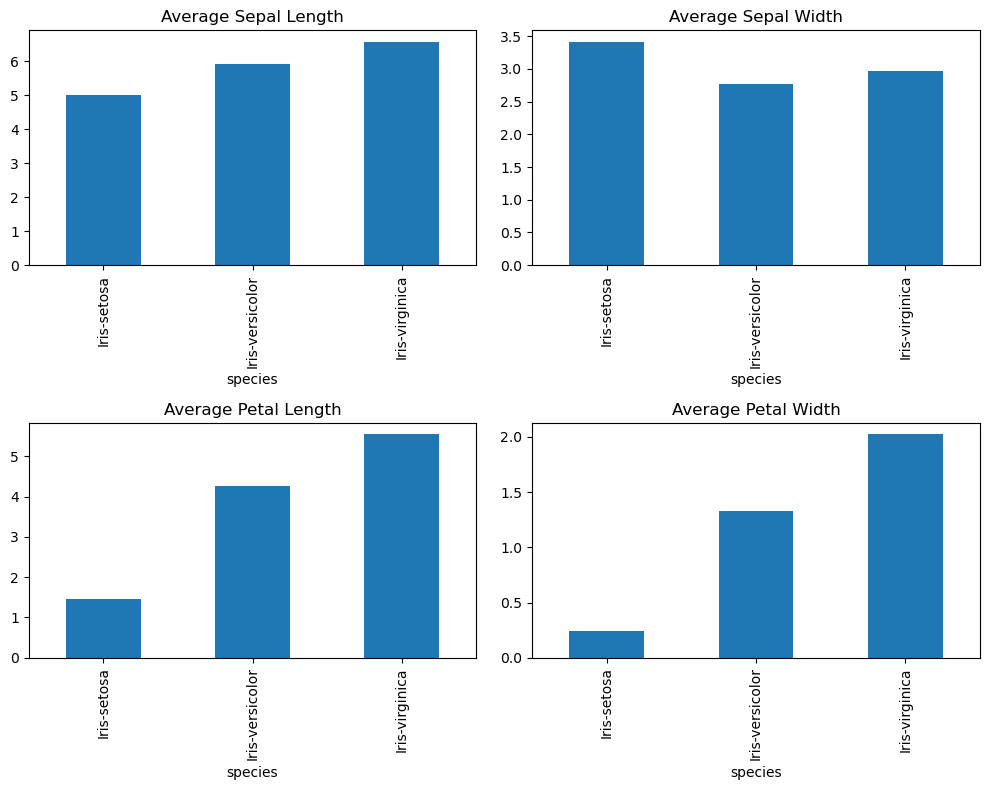

## Relationships Between Variables

At this stage, we will conduct a more in-depth analysis to verify if the conclusions and observations from the previous stage hold true across the entire sample.

|  | species | sepal_length min | sepal_length median | sepal_length max | sepal_width min | sepal_width median | sepal_width max | petal_length min | petal_length median | petal_length max | petal_width min | petal_width median | petal_width max |
| --- | --- | --- | --- | --- | --- | --- | --- | --- | --- | --- | --- | --- | --- |
| 0 | Iris-setosa | 4.3 | 5.0 | 5.8 | 2.3 | 3.4 | 4.4 | 1.0 | 1.50 | 1.9 | 0.1 | 0.2 | 0.6 |
| 1 | Iris-versicolor | 4.9 | 5.9 | 7.0 | 2.0 | 2.8 | 3.4 | 3.0 | 4.35 | 5.1 | 1.0 | 1.3 | 1.8 |
| 2 | Iris-virginica | 4.9 | 6.5 | 7.9 | 2.2 | 3.0 | 3.8 | 4.5 | 5.55 | 6.9 | 1.4 | 2.0 | 2.5 |

|  | species | sepal_length_min | sepal_length_median | sepal_length_max | sepal_width_min | sepal_width_median | sepal_width_max | petal_length_min | petal_length_median | petal_length_max | petal_width_min | petal_width_median | petal_width_max |
| --- | --- | --- | --- | --- | --- | --- | --- | --- | --- | --- | --- | --- | --- |
| 0 | Iris-setosa | 4.3 | 5.0 | 5.8 | 2.3 | 3.4 | 4.4 | 1.0 | 1.50 | 1.9 | 0.1 | 0.2 | 0.6 |
| 1 | Iris-versicolor | 4.9 | 5.9 | 7.0 | 2.0 | 2.8 | 3.4 | 3.0 | 4.35 | 5.1 | 1.0 | 1.3 | 1.8 |
| 2 | Iris-virginica | 4.9 | 6.5 | 7.9 | 2.2 | 3.0 | 3.8 | 4.5 | 5.55 | 6.9 | 1.4 | 2.0 | 2.5 |

## Observations on Differences Between Species

On the plot, we clearly see differences in measurements between the various iris species. **Setosa** has significantly smaller petals in both length and width. The remaining two species differ slightly from each other—**Versicolor** has slightly smaller petals compared to **Virginica**.

Let's proceed to visualize the median, minimum, and maximum values for each variable across the species.

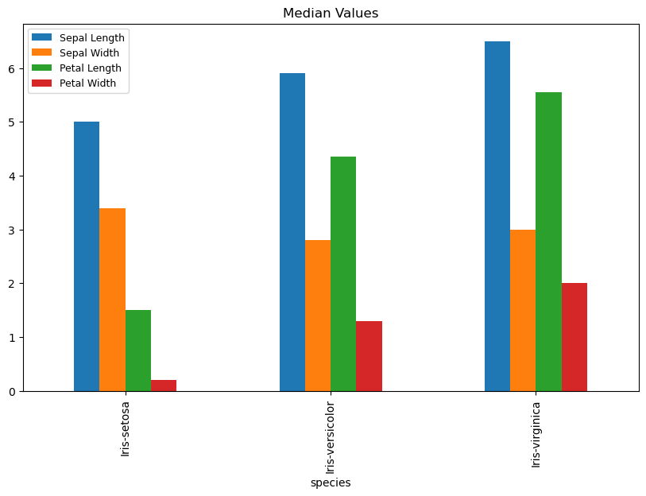

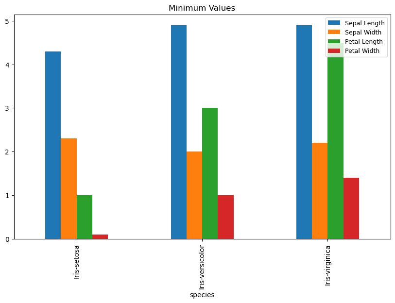

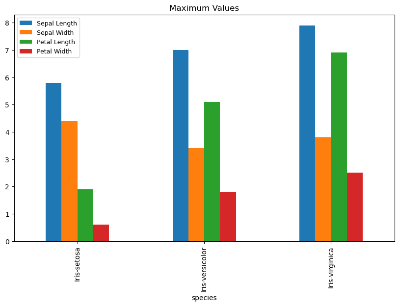

## Heatmaps of Correlation Matrices for Each Iris Species

Below, we see **three** heatmap plots—one for each iris species. Please note that all three correlation matrices differ from each other. We will examine this more closely in the summary.

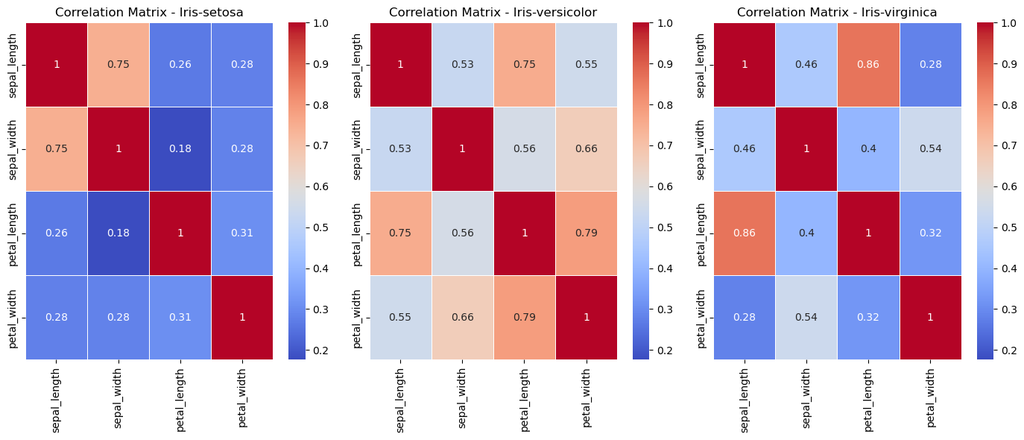

## Summary

After conducting the analysis, we arrive at the following conclusions:

[output not shown]